# Ajustement d’une V.A continue par adjustr

Abdessabour MOUTIK

2020-07-30

```r
db.mntsin <- read.csv2(path)
```

On uttilisera la deuxième colonne.

J’appelle alors ma fonction `getfitdistr` qui retourne une liste contenant l’*estimation*, la *p-value*, et si l’hypothèse nulle n’est pas rejetée, l’*AIC* pour les distributions données dans la colonne `distributions` du résultat. Simultanément, cette fonction crée les courbes des fonctions de distribution cumulative de **X** et des distributions ajustées.

```r
result <- getfitdistr(db.mntsin[[2]], short=FALSE, plots.as.vars = TRUE)
```

Les distributions utilisées sont :

```r
result$distributions
```

```
## [1] "gamma"       "lognormal"   "exponential"
```

On trace la courbe de la fonction de distribution cumulative empirique de **X**.

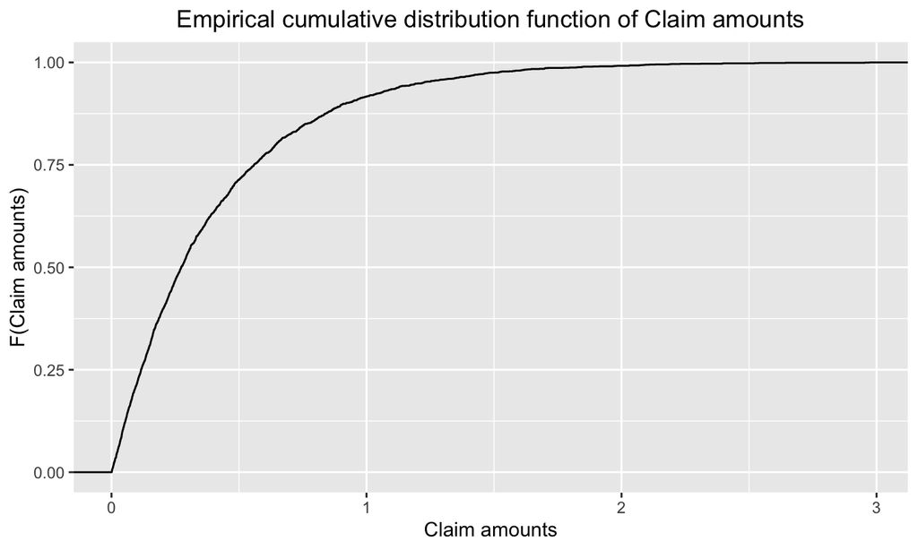

$\hat{F}_{X}$ Fonction de distribution cumulative empirique de $\mathbf{X}$

```r
result$plot
```

On trace la courbe de la fonction de distribution cumulative empirique de **X** et des fonctions de distribution cumulative des distributions **exponentielle, log-normale, gamma**.

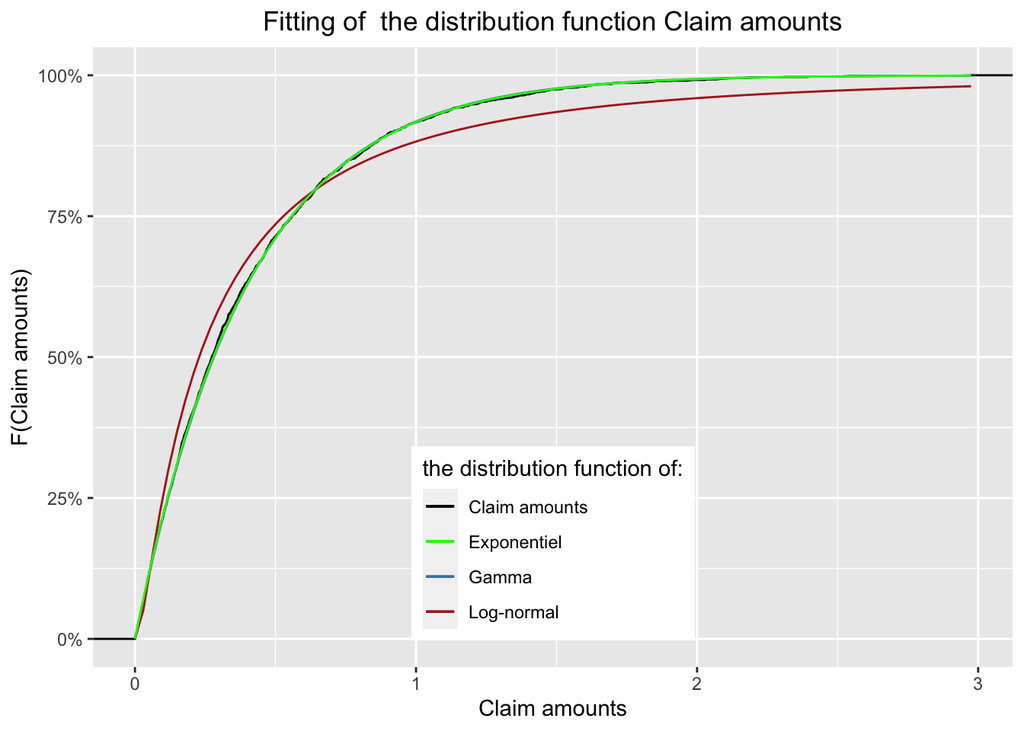

$\hat{F}_{X}$ et des F.D.Cs des distributions $\mathbf{gamma}$, $\mathbf{exponentielle}$ et $\mathbf{log-normale}$

```r
result$combinedplot
```

On remarque que la distribution de la loi **exponentielle** est la distribution la mieux ajustée à la distribution de **X**.

# Ajustement par une distribution de loi gamma

Après avoir utilisé `MASS::fitdistr(x, "gamma")` pour obtenir la distribution gamma ajustée dans le corps de notre fonction `getfitdistr`. On retrouvera l’*estimation* suivantes:

```r
result$gamma$estimate
```

```
##    shape     rate
## 1.016786 2.529258
```

En utilisant le test de **Kolmogorov-Smirnov** on retrouvera la
$$pvalue = 0.61412647229209$$

on a donc $pvalue > 5\%$

On accepte l’hypothèse Nulle $\mathcal{H}_0$. Donc la distribution de loi **gamma** permet de bien modéliser la distribution la valeur aléatoire **X**. La fonction `getfitdistr` retourne la valeur de l’*AIC*
$$AIC = 207.852712601341$$

# Ajustement par une distribution de loi log-normale

Après avoir utilisé `MASS::fitdistr(x, "lognormal")` pour obtenir la distribution log-normale ajustée dans le corps de notre fonction `getfitdistr`. On retrouvera l’*estimation* suivantes:

```r
result$lognormal$estimate
```

```
##   meanlog     sdlog
## -1.477864  1.244806
```

En utilisant le test de **Kolmogorov-Smirnov** on retrouvera la
$$pvalue = 1.67986979882073e-09$$

on a donc $pvalue < 5\%$

On rejete l’hypthèse Nulle $\mathcal{H}_0$. Donc la distribution de loi **log-normale** ne permet pas de modèlisé celle de **X**.

# Ajustement par une distribution de loi exponentielle

Après avoir utilisé `MASS::fitdistr(x, "exponential")` pour obtenir la distribution exponentielle ajustée dans le corps de notre fonction `getfitdistr`. On retrouvera l’*estimation* suivantes:

```r
result$exponential$estimate
```

```
##     rate
## 2.487504
```

En utilisant le test de **Kolmogorov-Smirnov** on retrouvera la
$$pvalue = 0.768252166387063$$

on a donc $pvalue > 5\%$

On accepte l’hypothèse Nulle $\mathcal{H}_0$. Donc la distribution de loi **exponentielle** permet de bien modéliser la distribution la valeur aléatoire **X**. La fonction `getfitdistr` retourne la valeur de l’*AIC*
$$AIC = 206.056699681226$$

## *Conclusion :* La distribution la mieux ajustée est celle de la loi exponentielle

On écrit :
$$\mathbf{X}\sim\mathcal{EXP}(2.49)$$